# 13. 다양한 그래프

# H. 통계치의 그래프

### 13.13 Q-Q 그래프 그리기

분위수-분위수(Q-Q) 그래프를 그려서 경험적 분포와 이론적 분포를 비교하기 위해 qqnorm()을 사용해 정규 분포와 비교한다.

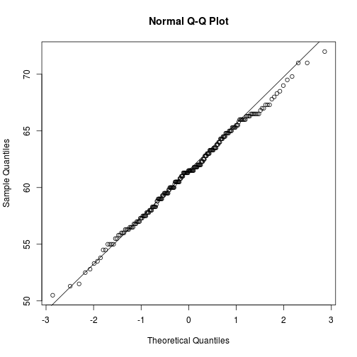

```r
library(gcookbook)

# height의 QQ 그래프
qqnorm(heightweight$heightIn)
qqline(heightweight$heightIn)
```

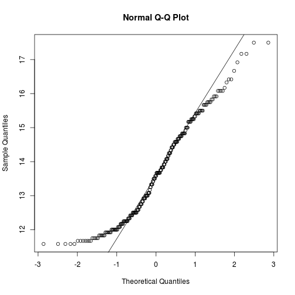

```r
# age의 QQ 그래프
qqnorm(heightweight$ageYear)
qqline(heightweight$ageYear)
```

heightln에 들어있는 점들은 그려진 선과 가까운데,  
이는 해당 점들의 분포가 정규분포와 유사하다는 뜻이다.  
ageYear의 점들은 선에서부터 먼데, 특히 왼쪽이 멀리 떨어져 있음을 볼 때  
분포가 비대칭이라는 사실을 알 수 있다.  
데이터의 분포를 보기 위해 Q-Q plot이나 히스토그램 등을 활용한다.

### 13.14 경험적 누적 분포 함수 그래프 그리기

데이터 세트의 경험적 누적 분포 함수  
(ECDF: empirical cumulative distribution function)을 그린다.

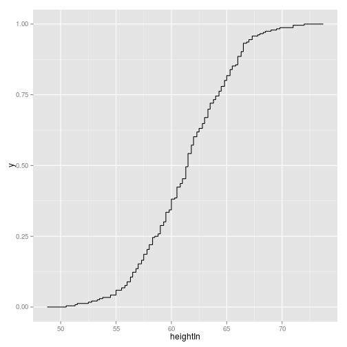

```r
library(gcookbook)

# hegithIn의 edcf
ggplot(heightweight, aes(x=heightIn)) + stat_ecdf()
```

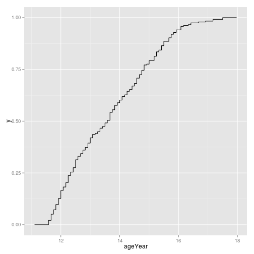

```r
# ageYear의 ecdf
ggplot(heightweight, aes(x=ageYear)) + stat_ecdf()
```

ECDF는 주어진 x 값과 같거나 그보다 작은 값인 관측의 비율이 얼마나 되는지를 보여준다.  
'경험적(empirical)'이라는 측면 때문에, 하나 이상의 관측이 존재하는 x 값마다  
선이 한 계단 올라가는 모양이다.

### 13.15 모자이크 그래프 그리기

분할표(contingencey table)를 시각화하는 모자이크 그래프를 만든다.

```r
# 데이터 살펴보기
UCBAdmissions
```

```
## , , Dept = A
##
##           Gender
## Admit      Male Female
##   Admitted  512     89
##   Rejected  313     19
##
## , , Dept = B
##
##           Gender
## Admit      Male Female
##   Admitted  353     17
##   Rejected  207      8
##
## , , Dept = C
##
##           Gender
## Admit      Male Female
##   Admitted  120    202
##   Rejected  205    391
##
## , , Dept = D
##
##           Gender
## Admit      Male Female
##   Admitted  138    131
##   Rejected  279    244
##
## , , Dept = E
##
##           Gender
## Admit      Male Female
##   Admitted   53     94
##   Rejected  138    299
##
## , , Dept = F
##
##           Gender
## Admit      Male Female
##   Admitted   22     24
##   Rejected  351    317
```

```r
# 평면적인(flat) 분할표를 출력
ftable(UCBAdmissions)
```

```
##                 Dept   A   B   C   D   E   F
## Admit    Gender
## Admitted Male        512 353 120 138  53  22
##          Female       89  17 202 131  94  24
## Rejected Male        313 207 205 279 138 351
##          Female       19   8 391 244 299 317
```

```r
dimnames(UCBAdmissions)
```

```
## $Admit
## [1] "Admitted" "Rejected"
##
## $Gender
## [1] "Male"   "Female"
##
## $Dept
## [1] "A" "B" "C" "D" "E" "F"
```

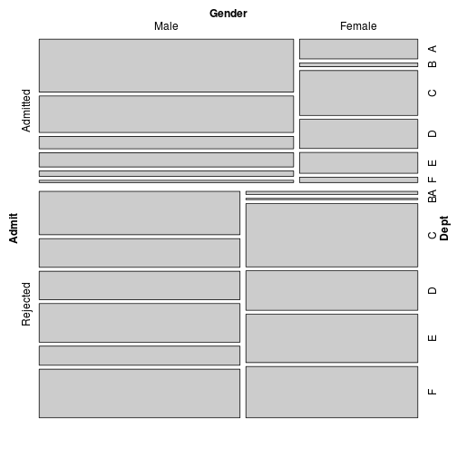

```r
# 패키지 설치
#install.packages("vcd")
library(vcd)

# Admit으로 나눈 뒤 Gender, 그 다음 Dept를 기준으로 나눈다.
# (변수를 입력한 순서대로 데이터가 나뉜다)
mosaic( ~ Admit + Gender + Dept, data=UCBAdmissions)
```

데이터를 나누는 순서를 변경하여 흥미로운 정보가 더 보일지 알아본다.

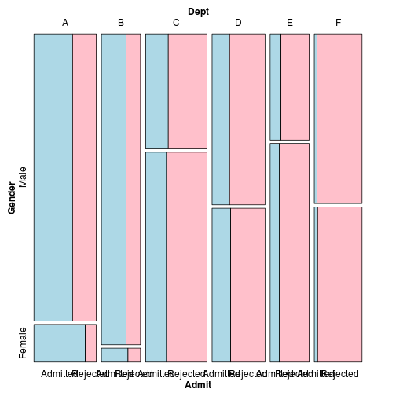

```r
# 변수를 학과, 성별로 먼저 분할한 다음, 허가/거절 셀을 나눈다.
mosaic( ~ Dept + Gender + Admit, data=UCBAdmissions,
    highlighting="Admit", highlighting_fill=c("lightblue", "pink"),
    direction=c("v","h","v"))
```

다른 분할 방향을 써도 무방하다.

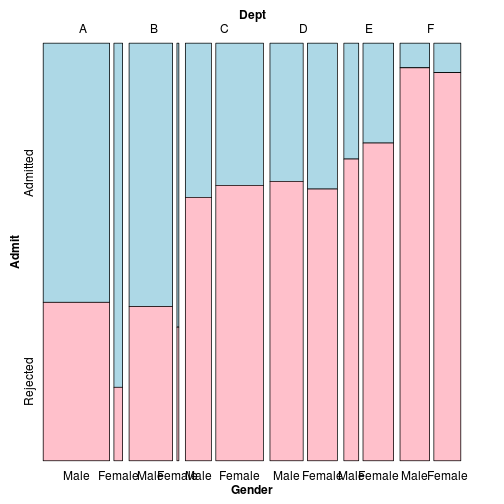

```r
# 나누는 방향을 다르게 결정
mosaic( ~ Dept + Gender + Admit, data=UCBAdmissions,
    highlighting="Admit", highlighting_fill=c("lightblue", "pink"),
    direction=c("v", "v", "h"))
```

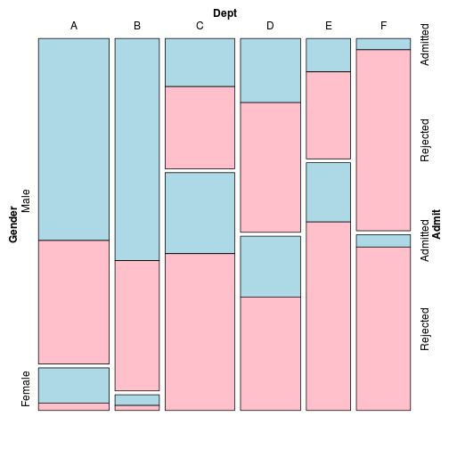

```r
# 이 순서로 나누면 남성과 여성 비교가 힘들다
mosaic( ~ Dept + Gender + Admit, data=UCBAdmissions,
    highlighting="Admit", highlighting_fill=c("lightblue", "pink"),
    direction=c("v", "h", "h"))
```

이 예제는 집단을 결합했을 때 하위 집단들 내에서 변수들의 관계와는 차이가 있을 수 있다는  
심슨의 역설(Simpson's paradox)을 보여준다.  
데이터를 분할하는 순서와 분할 방향을 바꾸면 데이터의 다른 측면을 찾아낼 수 있다.

### 13.16 파이 차트 만들기

파이 차트를 만들려면 pie() 함수를 사용한다.

```r
library(MASS)

# 변수 fold의 수준별 사건 개수를 표로 얻어낸다.
fold <- table(survey$Fold)
fold
```

```
##
##  L on R Neither  R on L
##      99      18     120
```

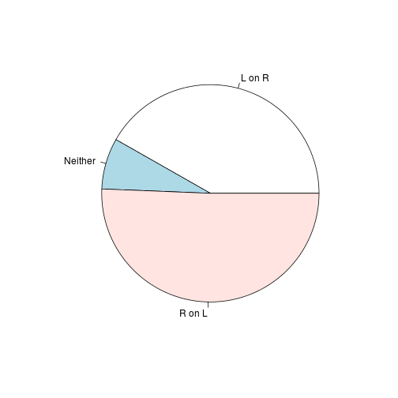

```r
# 파이 차트를 만든다
pie(fold)

# table객체 대신 이름이 있는 벡터 혹은 값 벡터와 라벨 벡터를 함께 전달해도 된다.
pie(c(99, 18, 120), labels=c("L on R", "Neither", "R on L"))
```

파이 차트는 빈번하게 남용되며, 파이 차트보다는 막대 그래프(또는 누적 막대 그래프)가  
더 효과적으로 정보를 전달하지는 않을지 고민해보아야 한다.

# I. 지도(map)

### 13.17 지도 그리기

지도를 만들려면 maps 패키지에서 지도 데이터를 불러온 다음 geom_polygon()을 사용하거나(채우기 색상이 있음),  
geom_path()를 사용한다(채우기 색상이 없음). 기본 좌표는 데카르트 좌표 평면이지만 coor_map()을 사용해 투영 방식을 지정할 수 있다.

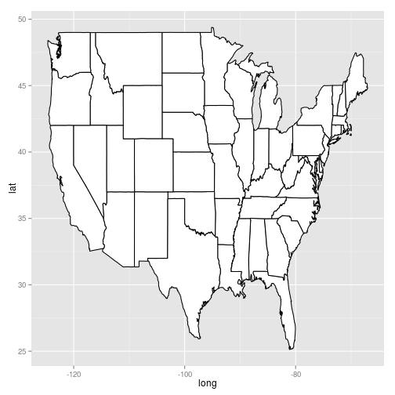

```r
# maps 패키지 설치
#install.packages("maps")
library(maps)

# 미국 지도 데이터를 가져온다
states_map <- map_data("state")

ggplot(states_map, aes(x=long, y=lat, group=group)) +
    geom_polygon(fill="white", colour="black")
```

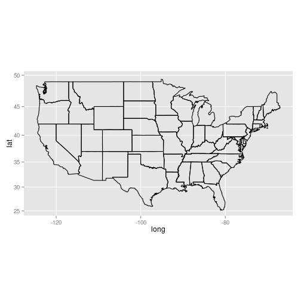

```r
# geom_path(채우기 없음)과 메르카토르(mercator) 투영
ggplot(states_map, aes(x=long, y=lat, group=group)) +
    geom_path() + coord_map("mercator")
```

map_data() 함수는 다음 열들이 있는 데이터 프레임을 반환한다.

| 옵션 | 설명 |
| --- | --- |
| long | 경도 |
| lat | 위도 |
| group | 각 다각형별 집단 분류 변수 |
| order | 집단 내에서 각각의 점을 연결하는 순서 |
| region | 지역명, 대체로 국가 이름 |
| subregion | 하위 지역명. 지역 내의 하위 지역들이며, 지역에는 여러 하위 지역 집단이 있을 수 있다. |

```r
# 세계 지도 데이터를 가져온다.
world_map <- map_data("world")
# 에러: maps package required for this functionality. Please install and try again.
head(world_map, 10)
```

```
##      long   lat group order region subregion
## 1  -133.4 58.42     1     1 Canada      <NA>
## 2  -132.3 57.16     1     2 Canada      <NA>
## 3  -132.0 56.99     1     3 Canada      <NA>
## 4  -131.9 56.74     1     4 Canada      <NA>
## 5  -130.2 56.10     1     5 Canada      <NA>
## 6  -130.0 55.91     1     6 Canada      <NA>
## 7  -130.0 55.92     1     7 Canada      <NA>
## 8  -130.0 55.86     1     8 Canada      <NA>
## 9  -130.0 55.43     1     9 Canada      <NA>
## 10 -130.1 55.05     1    10 Canada      <NA>
```

```r
# world 지도에서 독립적인 지도가 존재하지 않는 지역의 지도를 그리고 싶다면,
# 다음과 같이 먼저 지역 이름을 찾아본다.
sortmap <- sort(unique(world_map$region))
head(sortmap, 40)
```

```
##  [1] "Afghanistan"     "Albania"         "Algeria"
##  [4] "American Samoa"  "Andaman Islands" "Andorra"
##  [7] "Angola"          "Anguilla"        "Antarctica"
## [10] "Antigua"         "Aral Sea"        "Argentina"
## [13] "Aruba"           "Australia"       "Austria"
## [16] "Azores"          "Bahamas"         "Bahrain"
## [19] "Bangladesh"      "Barbados"        "Barbuda"
## [22] "Belgium"         "Belize"          "Benin"
## [25] "Bhutan"          "Black Sea"       "Bolivia"
## [28] "Bonaire"         "Botswana"        "Brazil"
## [31] "Brunei"          "Bulgaria"        "Burkina Faso"
## [34] "Burundi"         "California"      "Cambodia"
## [37] "Cameroon"        "Canada"          "Canary Islands"
## [40] "Cape Verde"
```

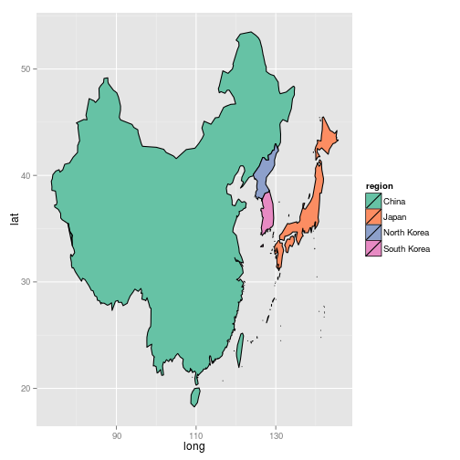

```r
# 특정한 지도에서 구체적인 지역 데이터를 가져오는 것도 가능하다.
east_asia <- map_data("world", region=c("Japan", "China", "North Korea",
                                        "South Korea"))
# 지역을 채우기 색상에 대입
ggplot(east_asia, aes(x=long, y=lat, group=group, fill=region)) +
    geom_polygon(colour="black") +
    scale_fill_brewer(palette="Set2")
```

만약 nz(New Zealand)처럼 해당 지역에 대한 독립적인 지도가 존재한다면  
world 지도에서 뽑아내는 것보다 훨씬 고해상도일 것이다.

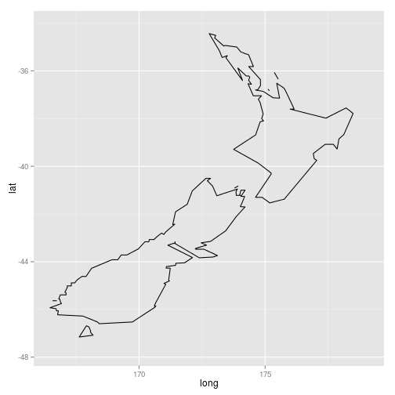

```r
# world 지도에서 뉴질랜드를 가져옴
nz1 <- map_data("world", region="New Zealand")
nz1 <- subset(nz1, long > 0 & lat > -48)        # Trim off islands
ggplot(nz1, aes(x=long, y=lat, group=group)) + geom_path()
```

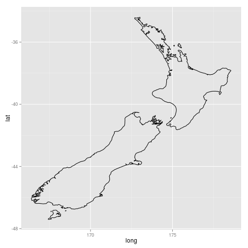

```r
# nz 지도에서 뉴질랜드 데이터를 가져옴
nz2 <- map_data("nz")
ggplot(nz2, aes(x=long, y=lat, group=group)) + geom_path()
```